# Lizards Parameter Estimation (Task 2)

Lucas Boyd

2/1/2022

## Overview

The following report examines lizard pitfall trap data in the Jornada Basin LTER site from 1989-2006. Firs, non-linear least squares (NLS) is used to fit a model of lizard weight as a function of its snout-vent length across all 13 lizard species. Then, NLS is used again to fit a model to male western whiptail lizards. Finally, the species-specific and general models are compared to determine which one is more effective.

**Data Citation:** Lightfoot, D. and W.G. Whitford. 2020. Lizard pitfall trap data from 11 NPP study locations at the Jornada Basin LTER site, 1989-2006 ver 37. Environmental Data Initiative. https://doi.org/10.6073/pasta/4a6e258fb49c31e222ecbbcfd128967f

## Setup

```r
knitr::opts_chunk$set(echo = TRUE, message = FALSE, warning = FALSE)
# attach packages
library(tidyverse)
library(broom)
library(purrr)
library(here)
library(janitor)
library(kableExtra)
library(modelr)
```

```r
# reading in the data
lizards <- read_csv(here("data", "lizard.csv")) %>%
  clean_names() %>%
  mutate(log_weight = log(weight)) %>% # log transforming the data - since we are using an exponential base equation
  mutate(log_length = log(sv_length)) %>%
  mutate(sex = case_when(
    sex == "M" ~ "Male",
    sex == "F" ~ "Female"
  )) %>%
  drop_na()
```

## Finding guess coefficients for use in NLS

The following equation was used as a starting point for the structure of the NLS model:
$$W = a(SVL)^b$$

```r
# running a linear regression on log transformed data to find coefficients
guess_model <- lm(log_weight ~ log_length, data = lizards)

tidy_guess <- tidy(guess_model) # tidy output of lm model

coef <- coefficients(guess_model) # pulling out coefficients for use in NLS
# estimate of coefficient b = 2.537 `r tidy_guess$estimate[2]`
# estmate of coefficent b = -8.475 `r tidy_guess$estimate[1]`

# storing a function of our model with coefficients
weight_function <- function(a, sv_length, b){
  weight = a*(sv_length)^b
  return(weight)
}
```

## Running NLS on all data

**Table 1** displays the results of NLS analysis on all lizards species, indicating the coefficients produced by the model, standard error, and signficance level.

```r
# running the NLS
lizards_nls <- nls(weight ~ weight_function(a, sv_length, b),
                  data = lizards,
                  start = list(b = coef[2], # starting with the coefficients we estimated from the linear model
                               a = exp(coef[1]))) # retransforming the intercept with exp()

nls_tidy <- tidy(lizards_nls) # tidy output of NLS model

# making a finalized table of the results of the NLS model
nls_tidy %>%
  select(-statistic) %>%
  mutate(p.value = case_when(
    p.value < 0.001 ~ "<0.001"
  )) %>%
kable(col.names = c("Terms", "Coefficients", "Standard Error", "P.Value"),
      digits = 4) %>%
  kable_minimal(full_width = FALSE)
```

| Terms | Coefficients | Standard Error | P.Value |
| --- | --- | --- | --- |
| b | 2.4532 | 0.027 | <0.001 |
| a | 0.0003 | 0.000 | <0.001 |

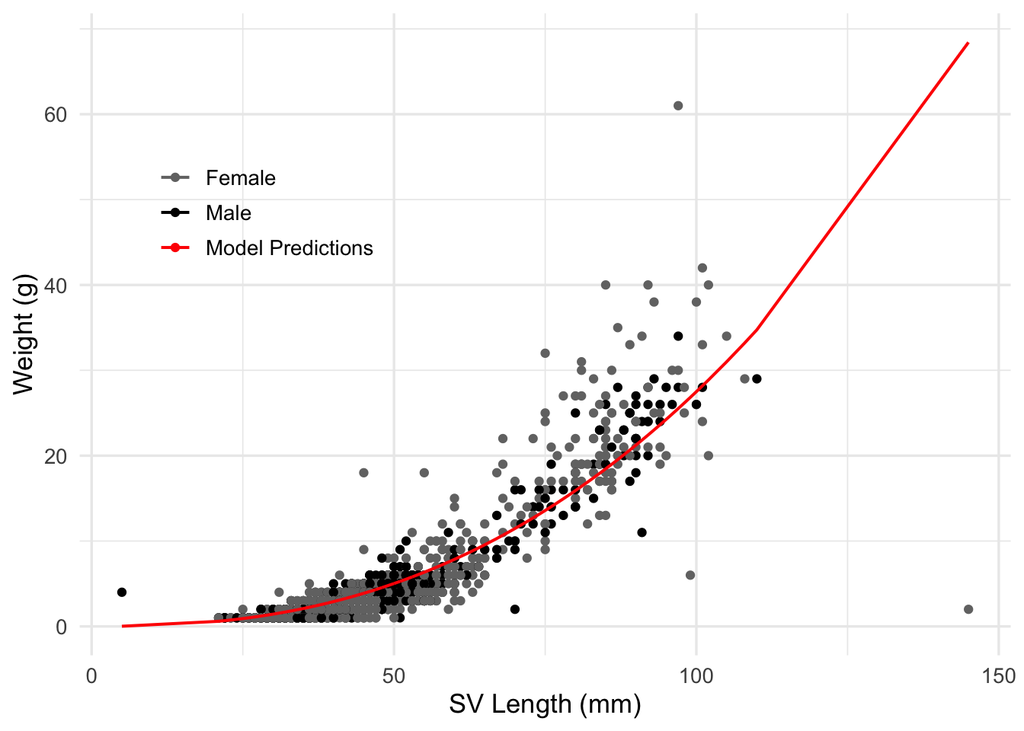

```r
# predicting data based on our NLS model
lizards_augment <- augment(lizards_nls)

# plotting the predicted data to actual data
ggplot() +
  geom_point(data = lizards, aes(
             x = sv_length,
             y = weight,
             color = sex)) +
  geom_line(data = lizards_augment, aes(
            x = sv_length,
            y = .fitted,
            color = "Model Predictions"),
            size = 0.7) +
  theme_minimal(13) +
  scale_color_manual(values = c("grey45", "black", "red")) +
  theme(legend.position = c(0.2,0.7), legend.title = element_blank()) +
  labs( x = "SV Length (mm)", y = "Weight (g)")
```

```r
# calculating RMSE
lizards_rmse <- rmse(lizards_nls, data = lizards)
```

**Fig. 1** compares SV length and weight for all lizard species, colored according to sex. The red line represents the NLS model trained on the data to predict weight as a function of SV length. RMSE for the NLS model was 2.791

## Running NLS on Male western whiptail lizards

**Table 2** displays the results of NLS analysis on male western whiptail lizards, indicating the coefficients produced by the model, standard error, and significance level.

```r
# filtering for male whiptails
whips <- lizards %>%
  filter(spp == "CNTI", sex == "Male")

# running linear regression on log transformed data to estimate starting coefficients
guess_whips <- lm(log_weight ~ log_length, data = whips)

tidy_whips_guess <- tidy(guess_model) # tidy output of guess model

whips_coef <- coefficients(guess_whips) # pulling out the coefficients for use in NLS

whips_nls <- nls(weight ~ weight_function(a, sv_length, b), # running NLS on male western whiptails
                  data = whips,
                  start = list(b = whips_coef[2], # starting from our guess coefficients
                               a = exp(whips_coef[1]))) # retransforming the intercept coefficient

whips_nls_tidy <- tidy(whips_nls) # tidy output of model

# finalized table of NLS model
whips_nls_tidy %>%
  select(-statistic) %>%
  mutate(p.value = case_when(
    p.value < 0.001 ~ "<0.001",
    p.value > 0.001 ~ as.character(round(p.value, 3)))) %>%
kable(col.names = c("Terms", "Coefficients", "Standard Error", "P Value"),
      digits = 4) %>%
  kable_minimal(full_width = FALSE)
```

| Terms | Coefficients | Standard Error | P Value |
| --- | --- | --- | --- |
| b | 2.3683 | 0.1800 | <0.001 |
| a | 0.0005 | 0.0004 | 0.219 |

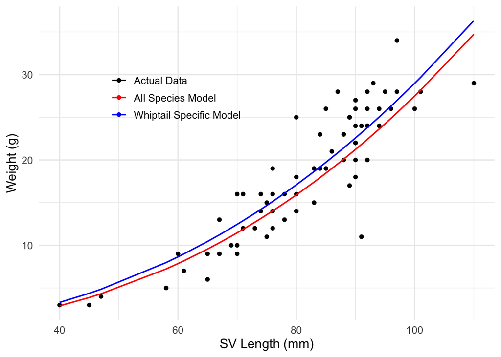

```r
# predicting data based on model
whips_augment <- augment(whips_nls)


# creating a dataframe with all data and predicted values from augment
whiptails_general <- data.frame(lizards, lizards_augment) %>%
  filter(spp == "CNTI", sex == "Male") # filtering for the whiptail subset

# visualizing fitted models against actual data
ggplot() +
  geom_point(data = whips, aes(
             x = sv_length,
             y = weight,
             color = "Actual Data")) +
  geom_line(data = whips_augment, aes(
            x = sv_length,
            y = .fitted,
            color = "Whiptail Specific Model"),
            size = 0.7) +
  geom_line(data = whiptails_general, aes(
            x = sv_length,
            y = .fitted,
            color = "All Species Model"),
            size = 0.7) +
  scale_color_manual(values = c("black", "red", "blue")) +
  theme_minimal(13) +
  labs( x = "SV Length (mm)", y = "Weight (g)") +
  theme(legend.title = element_blank(),
        legend.position = c(0.3, 0.72))
```

```r
# calculating RMSE
whips_rmse <- rmse(whips_nls, data = whips) # running whiptail model on whiptail subset
whips_rmse_general <- rmse(lizards_nls, data = whips) # running general model on whiptail subset
```

**Fig. 2** compares SV length and weight in male western whiptail lizards. The red line represents the NLS model trained on the entire lizard dataset including all species, while the blue line is the NLS model trained only on the subset of male western whiptail lizards. Both models predict weight as a function of SV length. The RMSE of the all species model was 3.562, while the RMSE of the whiptail specific model was 3.349. Thus the whiptail specific model is preferred when predicting weight from SV length of male western whiptail lizards, since the model’s lower RMSE shows that it is slightly more accurate and the model’s line appears to better fit the actual spread of data.